# ENHPATHY WORKSHOP GRaNPA

## Checking the prediction results

After the GRaNPA function has finished, you can plot and check the prediction results.

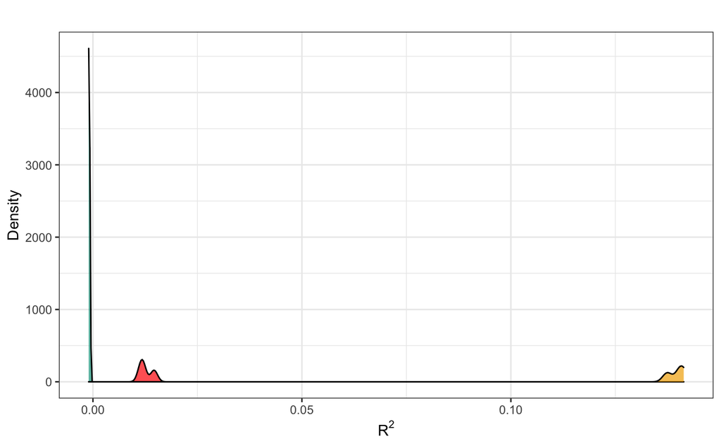

```r
# Plot the predictions
# The plot will be outputted to the console as well as saved to a pdf
#Replace the output folder with a folder of your choice

outdir = "/Users/servaas/Documents/EMBL/Workshops/ENHPATHY_2022/GRaNPA/"

GRaNPA::plot_GRaNPA_density(GRaNPA.object = GRaNPA_result, plot_name = "GRaNPA_prediction_density.pdf", outputFolder = outdir, width = 4, height = 4)
```

Take a look at the plot outputted by GRaNPA above. On the x-axis, we see the prediction power (R2). We also see different coloured density profiles for the real (yellow) and random networks (green and red). A performance greater than 0.05 (R2) for the real network indicates that the network is doing a good job at prediciting the DE data. A performance greater than 0.05 for a random network to predict random values indicates that the model is overfitting.

## Finding important TFs for the DE prediciton

Next to prediciting how well our GRN can predict differential gene expression, GRaNPA can also be used to identify the TFs that are important for the prediction. We can use the `plot_GRaNPA_TF_imp` function to see which TFs in our macrophage GRN are important for prediciting macropahge responses to Salmonella infection.

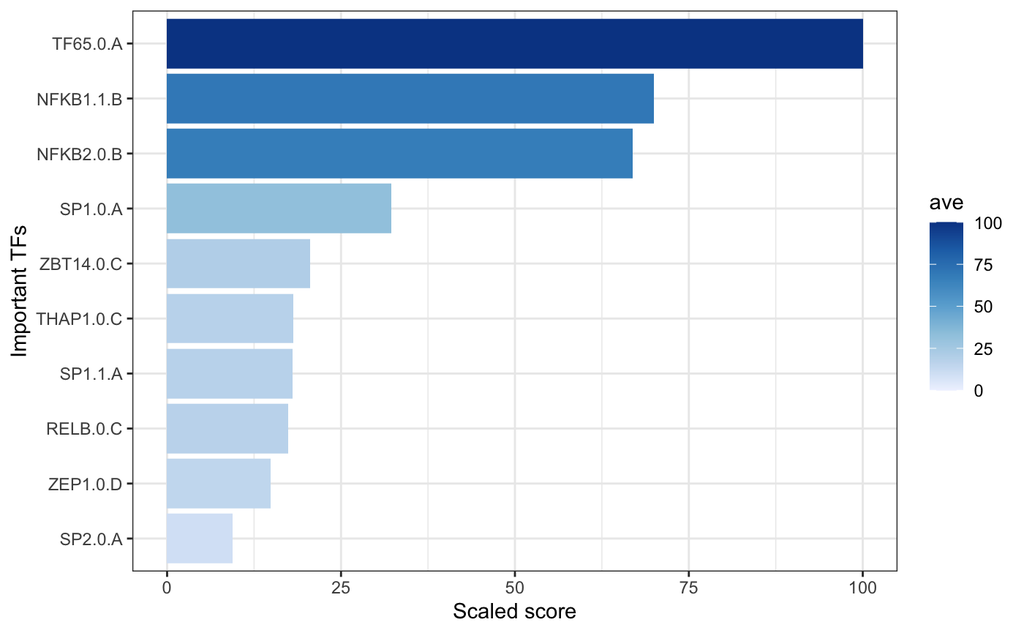

```r
#Plot TF importantce for the top 10 TFs
GRaNPA::plot_GRaNPA_TF_imp(GRaNPA.object = GRaNPA_result, plot_name = "GRaNPA_TF_imp.pdf", num = 10, output = outdir, width = 4, height = 4)
```

Take a look at the plot outputted by GRaNPA above. On the x-axis, we see scaled importance of every single TF (indicating on the y-axis) for predicting the DE data.

## Wrapping up

Hooray! You are now finished with the main workflow, and have a basic understanding of how to evaluate a GRN using GRaNPA! We encourage you to try out different DE datasets to identify candidate driver TFs for a specific expression response in your GRNs. We hope that the GRaNPA package is useful for your research and encourage you to contact us if you have any question or feature request!